# House Prices: Advanced Regression Techniques

Preethi, Sukanksha and Vivek

April 26, 2018

# 1 Introduction

> The Kaggle competition is to create generalizable model with low variance which predicts sales price of residential homes in Ames, Iowa. The data is partitioned into 50-50 set, naming train and test data set. The train data sets having total 81 variables with SalePrice as target variable and rest 79 are predictors (excluding ID since its unique to house# and is not good measurement for prediction) while test is having 80 variable(not having SalePrice).

> Libraries and Data Import

```r
#Import Library
library(missForest)
library(dplyr)
library(caret)
library(tidyverse)
```

```r
library(ggplot2)


#Data Extraction
getwd()
```

```
## [1] "C:/Users/user/Desktop/Statistics and Predictive Analytics/Project"
```

```r
test <- read.csv("test.csv",stringsAsFactors = TRUE)
train <- read.csv("train.csv",stringsAsFactors = TRUE)
```

# 2 Data modeling and cleaning

> 1. In our train and test dataset,we need to transform NA values with meaningful values for some variables-Alley,Fireplaces,PoolQC ,Fence ,BsmtQual, BsmtCond,BsmtExposure, BsmtFinType1,BsmtFinType2,GarageType,GarageCond,GarageFinish,GarageQual ,MiscFeature

```r
#Data Transformation

#1.For Alley variable, converting NA to NoAlley as NA refers to NoAlley from metadata.
train$Alley <- as.character(train$Alley)
train$Alley <- ifelse(is.na(train$Alley),'NoAlley', train$Alley)
train$Alley <- factor(train$Alley)

test$Alley <- as.character(test$Alley)
test$Alley <- ifelse(is.na(test$Alley),'NoAlley', test$Alley)
test$Alley <- factor(test$Alley)


#2.For PoolQC variable, converting NA to NoPool as NA refers to NoPool from metadata.
train$PoolQC <- as.character(train$PoolQC)
train$PoolQC <- ifelse(is.na(train$PoolQC),'NoPool', train$PoolQC)
train$PoolQC <- factor(train$PoolQC)


test$PoolQC <- as.character(test$PoolQC)
test$PoolQC <- ifelse(is.na(test$PoolQC),'NoPool', test$PoolQC)
test$PoolQC <- factor(test$PoolQC)



#3.For FireplaceQu variable, converting NA to NoFireplace as NA refers to NoFireplace from metadata.
train$FireplaceQu <- as.character(train$FireplaceQu)
train$FireplaceQu <- ifelse(is.na(train$FireplaceQu),'NoFireplace', train$FireplaceQu)
train$FireplaceQu <- factor(train$FireplaceQu)


test$FireplaceQu <- as.character(test$FireplaceQu)
test$FireplaceQu <- ifelse(is.na(test$FireplaceQu),'NoFireplace', test$FireplaceQu)
test$FireplaceQu <- factor(test$FireplaceQu)


#4.For Fence variable, converting NA to NoFence as NA refers to NoFence from metadata.
train$Fence <- as.character(train$Fence)
train$Fence <- ifelse(is.na(train$Fence),'NoFence',train$Fence)
train$Fence <- factor(train$Fence)


test$Fence <- as.character(test$Fence)
test$Fence <- ifelse(is.na(test$Fence),'NoFence',test$Fence)
test$Fence <- factor(test$Fence)


#5.Converting NA to NoMisc as NA refers to NoMisc from metadata.
train$MiscFeature <- as.character(train$MiscFeature)
train$MiscFeature <- ifelse(is.na(train$MiscFeature),'NoMisc',train$MiscFeature)
train$MiscFeature <- factor(train$MiscFeature)


test$MiscFeature <- as.character(test$MiscFeature)
test$MiscFeature <- ifelse(is.na(test$MiscFeature),'NoMisc',test$MiscFeature)
test$MiscFeature <- factor(test$MiscFeature)


#6.For BsmtQual variable, converting NA to NoBasemet as NA refers to NoBasement from metadata.
train$BsmtQual <- as.character(train$BsmtQual)
train$BsmtQual <- ifelse(is.na(train$BsmtQual),'NoBasement',train$BsmtQual)
train$BsmtQual <- factor(train$BsmtQual)


test$BsmtQual <- as.character(test$BsmtQual)
test$BsmtQual <- ifelse(is.na(test$BsmtQual),'NoBasement',test$BsmtQual)
test$BsmtQual <- factor(test$BsmtQual)



#7.For BsmtCond, converting NA to NoBasemet as NA refers to NoBasement from metadata.
train$BsmtCond <- as.character(train$BsmtCond)
train$BsmtCond <- ifelse(is.na(train$BsmtCond),'NoBasement',train$BsmtCond)
train$BsmtCond <- factor(train$BsmtCond)


test$BsmtCond <- as.character(test$BsmtCond)
test$BsmtCond <- ifelse(is.na(test$BsmtCond),'NoBasement',test$BsmtCond)
test$BsmtCond <- factor(test$BsmtCond)


#8.For BsmtExposure, converting NA to NoBasemet as NA refers to NoBasement from metadata.
train$BsmtExposure <- as.character(train$BsmtExposure)
train$BsmtExposure <- ifelse(is.na(train$BsmtExposure),'NoBasement',train$BsmtExposure)
train$BsmtExposure <- factor(train$BsmtExposure)


test$BsmtExposure <- as.character(test$BsmtExposure)
test$BsmtExposure <- ifelse(is.na(test$BsmtExposure),'NoBasement',test$BsmtExposure)
test$BsmtExposure <- factor(test$BsmtExposure)


#9.For BsmtFinType1, converting NA to NoBasemet as NA refers to NoBasement from metadata.
train$BsmtFinType1 <- as.character(train$BsmtFinType1)
train$BsmtFinType1 <- ifelse(is.na(train$BsmtFinType1),'NoBasement',train$BsmtFinType1)
train$BsmtFinType1 <- factor(train$BsmtFinType1)


test$BsmtFinType1 <- as.character(test$BsmtFinType1)
test$BsmtFinType1 <- ifelse(is.na(test$BsmtFinType1),'NoBasement',test$BsmtFinType1)
test$BsmtFinType1 <- factor(test$BsmtFinType1)


#10.For BsmtFinType2, converting NA to NoBasemet as NA refers to NoBasement from metadata.
train$BsmtFinType2 <- as.character(train$BsmtFinType2)
train$BsmtFinType2 <- ifelse(is.na(train$BsmtFinType2),'NoBasement',train$BsmtFinType2)
train$BsmtFinType2 <- factor(train$BsmtFinType2)


test$BsmtFinType2 <- as.character(test$BsmtFinType2)
test$BsmtFinType2 <- ifelse(is.na(test$BsmtFinType2),'NoBasement',test$BsmtFinType2)
test$BsmtFinType2 <- factor(test$BsmtFinType2)


#11.For GarageType, converting NA to NoGarageType as NA refers to NoGarage from metadata.
train$GarageType <- as.character(train$GarageType)
train$GarageType <- ifelse(is.na(train$GarageType),'NoGarage',train$GarageType)
train$GarageType <- factor(train$GarageType)


test$GarageType <- as.character(test$GarageType)
test$GarageType <- ifelse(is.na(test$GarageType),'NoGarage',test$GarageType)
test$GarageType <- factor(test$GarageType)


#12.For GarageCond, Converting NA to NoGarage as NA refers to NoGarage from metadata.
train$GarageCond <- as.character(train$GarageCond)
train$GarageCond <- ifelse(is.na(train$GarageCond),'NoGarage',train$GarageCond)
train$GarageCond <- factor(train$GarageCond)


test$GarageCond <- as.character(test$GarageCond)
test$GarageCond <- ifelse(is.na(test$GarageCond),'NoGarage',test$GarageCond)
test$GarageCond <- factor(test$GarageCond)


#13.For GarageFinish, Converting NA to NoGarage as NA refers to NoGarage from metadata.
train$GarageFinish <- as.character(train$GarageFinish)
train$GarageFinish <- ifelse(is.na(train$GarageFinish),'NoGarage',train$GarageFinish)
train$GarageFinish <- factor(train$GarageFinish)


test$GarageFinish <- as.character(test$GarageFinish)
test$GarageFinish <- ifelse(is.na(test$GarageFinish),'NoGarage',test$GarageFinish)
test$GarageFinish <- factor(test$GarageFinish)



#14.For GGarageQual, converting NA to NoGarage as NA refers to NoGarage from metadata.
train$GarageQual <- as.character(train$GarageQual)
train$GarageQual <- ifelse(is.na(train$GarageQual),'NoGarage',train$GarageQual)
train$GarageQual <- factor(train$GarageQual)


test$GarageQual <- as.character(test$GarageQual)
test$GarageQual <- ifelse(is.na(test$GarageQual),'NoGarage',test$GarageQual)
test$GarageQual <- factor(test$GarageQual)
```

> 2. Combining both test and train data by removing SalesPrice variable from train data

```r
#binding two dataframes

SP <- train[,c("Id", "SalePrice")]

# removing SalePrice variable to bind train and test
newtrain = subset(train, select = -c(SalePrice) )
# binding train and test
join <- rbind(newtrain,test)
```

> 3. Used missForest function for NA imputation

```r
joinmis <- missForest(join)$ximp
```

```
##   missForest iteration 1 in progress...
```

```
## done!
##   missForest iteration 2 in progress...
```

```
## done!
##   missForest iteration 3 in progress...
```

```
## done!
##   missForest iteration 4 in progress...
```

```
## done!
##   missForest iteration 5 in progress...
```

```
## done!
##   missForest iteration 6 in progress...
```

```
## done!
```

```r
summary(joinmis)
```

```
##        Id           MSSubClass        MSZoning     LotFrontage
##  Min.   :   1.0   Min.   : 20.00   C (all):  25   Min.   : 21.00
##  1st Qu.: 730.5   1st Qu.: 20.00   FV     : 139   1st Qu.: 60.00
##  Median :1460.0   Median : 50.00   RH     :  26   Median : 70.00
##  Mean   :1460.0   Mean   : 57.14   RL     :2267   Mean   : 69.88
##  3rd Qu.:2189.5   3rd Qu.: 70.00   RM     : 462   3rd Qu.: 80.00
##  Max.   :2919.0   Max.   :190.00                  Max.   :313.00
##
##     LotArea        Street         Alley      LotShape   LandContour
##  Min.   :  1300   Grvl:  12   Grvl   : 120   IR1: 968   Bnk: 117
##  1st Qu.:  7478   Pave:2907   NoAlley:2721   IR2:  76   HLS: 120
##  Median :  9453               Pave   :  78   IR3:  16   Low:  60
##  Mean   : 10168                              Reg:1859   Lvl:2622
##  3rd Qu.: 11570
##  Max.   :215245
##
##   Utilities      LotConfig    LandSlope   Neighborhood    Condition1
##  AllPub:2918   Corner : 511   Gtl:2778   NAmes  : 443   Norm   :2511
##  NoSeWa:   1   CulDSac: 176   Mod: 125   CollgCr: 267   Feedr  : 164
##                FR2    :  85   Sev:  16   OldTown: 239   Artery :  92
##                FR3    :  14              Edwards: 194   RRAn   :  50
##                Inside :2133              Somerst: 182   PosN   :  39
##                                          NridgHt: 166   RRAe   :  28
##                                          (Other):1428   (Other):  35
##    Condition2     BldgType      HouseStyle    OverallQual
##  Norm   :2889   1Fam  :2425   1Story :1471   Min.   : 1.000
##  Feedr  :  13   2fmCon:  62   2Story : 872   1st Qu.: 5.000
##  Artery :   5   Duplex: 109   1.5Fin : 314   Median : 6.000
##  PosA   :   4   Twnhs :  96   SLvl   : 128   Mean   : 6.089
##  PosN   :   4   TwnhsE: 227   SFoyer :  83   3rd Qu.: 7.000
##  RRNn   :   2                 2.5Unf :  24   Max.   :10.000
##  (Other):   2                 (Other):  27
##   OverallCond      YearBuilt     YearRemodAdd    RoofStyle
##  Min.   :1.000   Min.   :1872   Min.   :1950   Flat   :  20
##  1st Qu.:5.000   1st Qu.:1954   1st Qu.:1965   Gable  :2310
##  Median :5.000   Median :1973   Median :1993   Gambrel:  22
##  Mean   :5.565   Mean   :1971   Mean   :1984   Hip    : 551
##  3rd Qu.:6.000   3rd Qu.:2001   3rd Qu.:2004   Mansard:  11
##  Max.   :9.000   Max.   :2010   Max.   :2010   Shed   :   5
##
```

[output cut: 97 more lines]

```
##  GdPrv  : 118   Gar2  :   5   Min.   :    0.00   Min.   : 1.000
##  GdWo   : 112   NoMisc:2814   1st Qu.:    0.00   1st Qu.: 4.000
##  MnPrv  : 329   Othr  :   4   Median :    0.00   Median : 6.000
##  MnWw   :  12   Shed  :  95   Mean   :   50.83   Mean   : 6.213
##  NoFence:2348   TenC  :   1   3rd Qu.:    0.00   3rd Qu.: 8.000
##                               Max.   :17000.00   Max.   :12.000
##
##      YrSold        SaleType    SaleCondition
##  Min.   :2006   WD     :2526   Abnorml: 190
##  1st Qu.:2007   New    : 239   AdjLand:  12
##  Median :2008   COD    :  87   Alloca :  24
##  Mean   :2008   ConLD  :  26   Family :  46
##  3rd Qu.:2009   CWD    :  12   Normal :2402
##  Max.   :2010   ConLI  :   9   Partial: 245
##                 (Other):  20
```

> 5. After imputing NA, dividing the data again into train and test set using the row count

```r
trainmis <- joinmis %>%
  slice(1:1460)

trainmis$SalePrice <- SP

testmis <- joinmis %>%
  slice(1461:2919)

summary(joinmis)
```

```
##        Id           MSSubClass        MSZoning     LotFrontage
##  Min.   :   1.0   Min.   : 20.00   C (all):  25   Min.   : 21.00
##  1st Qu.: 730.5   1st Qu.: 20.00   FV     : 139   1st Qu.: 60.00
##  Median :1460.0   Median : 50.00   RH     :  26   Median : 70.00
##  Mean   :1460.0   Mean   : 57.14   RL     :2267   Mean   : 69.88
##  3rd Qu.:2189.5   3rd Qu.: 70.00   RM     : 462   3rd Qu.: 80.00
##  Max.   :2919.0   Max.   :190.00                  Max.   :313.00
##
##     LotArea        Street         Alley      LotShape   LandContour
##  Min.   :  1300   Grvl:  12   Grvl   : 120   IR1: 968   Bnk: 117
##  1st Qu.:  7478   Pave:2907   NoAlley:2721   IR2:  76   HLS: 120
##  Median :  9453               Pave   :  78   IR3:  16   Low:  60
##  Mean   : 10168                              Reg:1859   Lvl:2622
##  3rd Qu.: 11570
##  Max.   :215245
##
##   Utilities      LotConfig    LandSlope   Neighborhood    Condition1
##  AllPub:2918   Corner : 511   Gtl:2778   NAmes  : 443   Norm   :2511
##  NoSeWa:   1   CulDSac: 176   Mod: 125   CollgCr: 267   Feedr  : 164
##                FR2    :  85   Sev:  16   OldTown: 239   Artery :  92
##                FR3    :  14              Edwards: 194   RRAn   :  50
##                Inside :2133              Somerst: 182   PosN   :  39
##                                          NridgHt: 166   RRAe   :  28
##                                          (Other):1428   (Other):  35
##    Condition2     BldgType      HouseStyle    OverallQual
##  Norm   :2889   1Fam  :2425   1Story :1471   Min.   : 1.000
##  Feedr  :  13   2fmCon:  62   2Story : 872   1st Qu.: 5.000
##  Artery :   5   Duplex: 109   1.5Fin : 314   Median : 6.000
##  PosA   :   4   Twnhs :  96   SLvl   : 128   Mean   : 6.089
##  PosN   :   4   TwnhsE: 227   SFoyer :  83   3rd Qu.: 7.000
##  RRNn   :   2                 2.5Unf :  24   Max.   :10.000
##  (Other):   2                 (Other):  27
##   OverallCond      YearBuilt     YearRemodAdd    RoofStyle
##  Min.   :1.000   Min.   :1872   Min.   :1950   Flat   :  20
##  1st Qu.:5.000   1st Qu.:1954   1st Qu.:1965   Gable  :2310
##  Median :5.000   Median :1973   Median :1993   Gambrel:  22
##  Mean   :5.565   Mean   :1971   Mean   :1984   Hip    : 551
##  3rd Qu.:6.000   3rd Qu.:2001   3rd Qu.:2004   Mansard:  11
##  Max.   :9.000   Max.   :2010   Max.   :2010   Shed   :   5
##
```

[output cut: 97 more lines]

```
##  GdPrv  : 118   Gar2  :   5   Min.   :    0.00   Min.   : 1.000
##  GdWo   : 112   NoMisc:2814   1st Qu.:    0.00   1st Qu.: 4.000
##  MnPrv  : 329   Othr  :   4   Median :    0.00   Median : 6.000
##  MnWw   :  12   Shed  :  95   Mean   :   50.83   Mean   : 6.213
##  NoFence:2348   TenC  :   1   3rd Qu.:    0.00   3rd Qu.: 8.000
##                               Max.   :17000.00   Max.   :12.000
##
##      YrSold        SaleType    SaleCondition
##  Min.   :2006   WD     :2526   Abnorml: 190
##  1st Qu.:2007   New    : 239   AdjLand:  12
##  Median :2008   COD    :  87   Alloca :  24
##  Mean   :2008   ConLD  :  26   Family :  46
##  3rd Qu.:2009   CWD    :  12   Normal :2402
##  Max.   :2010   ConLI  :   9   Partial: 245
##                 (Other):  20
```

> 6. Finding variable which have nearzero variance

```r
nearZeroVar(joinmis,  names= T)
```

```
##  [1] "Street"        "Alley"         "LandContour"   "Utilities"
##  [5] "LandSlope"     "Condition2"    "RoofMatl"      "BsmtCond"
##  [9] "BsmtFinType2"  "BsmtFinSF2"    "Heating"       "LowQualFinSF"
## [13] "KitchenAbvGr"  "Functional"    "OpenPorchSF"   "EnclosedPorch"
## [17] "X3SsnPorch"    "ScreenPorch"   "PoolArea"      "PoolQC"
## [21] "MiscFeature"   "MiscVal"
```

> 7. Removing variables which have near zero variance

```r
joinmis = subset(joinmis, select = -c(Street,Alley,LandContour,Utilities,LandSlope,Condition2,RoofMatl,
                                        BsmtCond,BsmtFinType2,BsmtFinSF2,Heating,LowQualFinSF,OpenPorchSF,
                                        EnclosedPorch,X3SsnPorch,ScreenPorch,KitchenAbvGr,Functional,
                                        PoolArea,PoolQC,MiscFeature,MiscVal))
names(joinmis)
```

```
##  [1] "Id"            "MSSubClass"    "MSZoning"      "LotFrontage"
##  [5] "LotArea"       "LotShape"      "LotConfig"     "Neighborhood"
##  [9] "Condition1"    "BldgType"      "HouseStyle"    "OverallQual"
## [13] "OverallCond"   "YearBuilt"     "YearRemodAdd"  "RoofStyle"
## [17] "Exterior1st"   "Exterior2nd"   "MasVnrType"    "MasVnrArea"
## [21] "ExterQual"     "ExterCond"     "Foundation"    "BsmtQual"
## [25] "BsmtExposure"  "BsmtFinType1"  "BsmtFinSF1"    "BsmtUnfSF"
## [29] "TotalBsmtSF"   "HeatingQC"     "CentralAir"    "Electrical"
## [33] "X1stFlrSF"     "X2ndFlrSF"     "GrLivArea"     "BsmtFullBath"
## [37] "BsmtHalfBath"  "FullBath"      "HalfBath"      "BedroomAbvGr"
## [41] "KitchenQual"   "TotRmsAbvGrd"  "Fireplaces"    "FireplaceQu"
## [45] "GarageType"    "GarageYrBlt"   "GarageFinish"  "GarageCars"
## [49] "GarageArea"    "GarageQual"    "GarageCond"    "PavedDrive"
## [53] "WoodDeckSF"    "Fence"         "MoSold"        "YrSold"
## [57] "SaleType"      "SaleCondition"
```

> 8.Extracting train and test set from join(imputed) dataset

```r
trainmis <- joinmis%>%
slice(1:1460)


#extracting test set from join(imputed) dataset
testmis <- joinmis %>%
slice(1461:2919)

trainmisf <- merge(trainmis,SP,by="Id")
```

> 9. To check the skewness of the output variable we decided to plot histogram. As shown in figure 1, the results showed us that the outcome variable is right skew and it is not normally distributed.

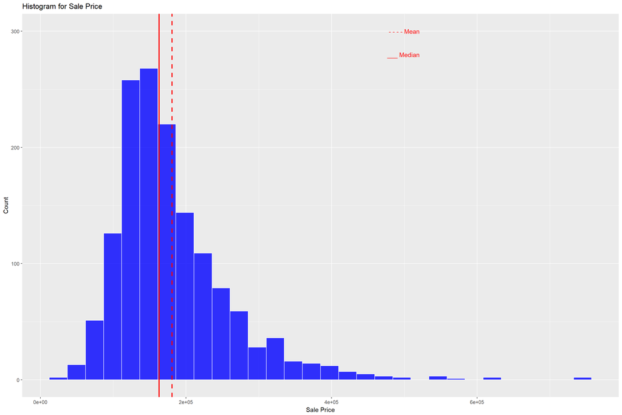

```r
ggplot(data = train , aes(x = (train$SalePrice)))+
geom_histogram(fill = 'blue',col = 'white' , alpha=0.8)+
geom_vline(xintercept = median(train$SalePrice), col = 'red',size = 1)+
geom_vline(xintercept = mean(train$SalePrice),col = 'red', size = 1,lty = 2)+
labs(title = "Histogram for Sale Price", x="Sale Price", y="Count")+
annotate( "text",label = "- - - - Mean", x = 500000, y = 300 ,col = 'red')+
annotate( "text",label = "___ Median ", x = 500000, y = 280, col = 'red')
```

>10. . To make the distribution normal, we logged the outcome variable SalePrice. The result was plotted using ggplot and found to be normally distributed, as shown in Figure 2.

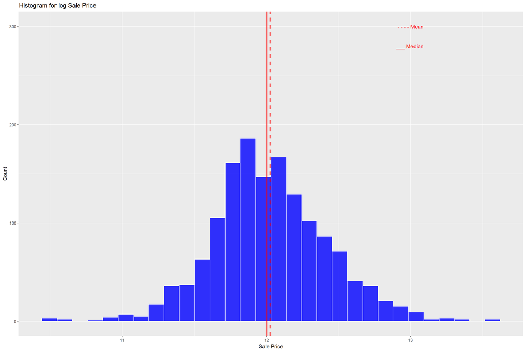

```r
ggplot(data = train , aes(x = log(train$SalePrice)))+
geom_histogram(fill = 'blue',col = 'white' , alpha=0.8)+
geom_vline(xintercept = median(log(train$SalePrice)), col = 'red',size = 1)+
geom_vline(xintercept = mean(log(train$SalePrice)),col = 'red', size = 1,lty = 2)+
labs(title = "Histogram for log Sale Price", x="Sale Price", y="Count")+
annotate( "text",label = "- - - - Mean", x = 13, y = 300 ,col = 'red')+
annotate( "text",label = "___ Median ", x = 13, y = 280, col = 'red')
```

>11.. Create the model for the outcome variable log(SalePrice)